# Lecture 7 - Generalized Linear Model

# Generalized Linear Model

Generalized linear models are extensions of traditional regression models that allow the mean to depend on the explanatory variables through a link function, and the response variable to be any member of a set of distributions called the exponential family (e.g., Normal, Poisson, Binomial). We can use the function `glm()` to work with generalized linear models in R.

- Classical linear model: $y=X\beta+\varepsilon$
  - Random component: $y_i \sim N(\mu_i,\sigma^2)$
  - Systematic component: linear predictor $\eta$ defined by $\eta=\sum_{j=1}^px_j\beta_j$
  - Link function: $\mu=\eta$

Extending above to: exponential family distribution for the random part, monotone differentiable link function for the systematic part.

- Component of the GLM:
  - Systematic component: Identifies the set of explanatory variables
    - Linear predictor $\eta=\sum_{j=1}^px_j\beta_j$
    - Link function $\eta=g(\mu)$, $\mu=E(y)$
  - Random component: Identifies dependent variable and its probability distribution $y\sim$exponential family
    - $f(y,\theta,\phi)=exp\{(y\theta-b(\theta))/\phi+c(y,\phi)\}$
    - Binary Responses -> Binomial Distribution
    - Count Responses -> Poisson Distribution (or Negative Binomial)
    - Positive and Skewed Responses -> Gamma Distribution
  - Link function: Identifies a function of the mean that is a linear function of the explanatory variables
    - log link: $\eta=\log(\mu)$, $\mu=e^\eta$
    - logit link: $\eta=\log(\frac{\mu}{1-\mu})=logit(\mu)$, $\mu=\frac{e^\eta}{1+e^\eta}$

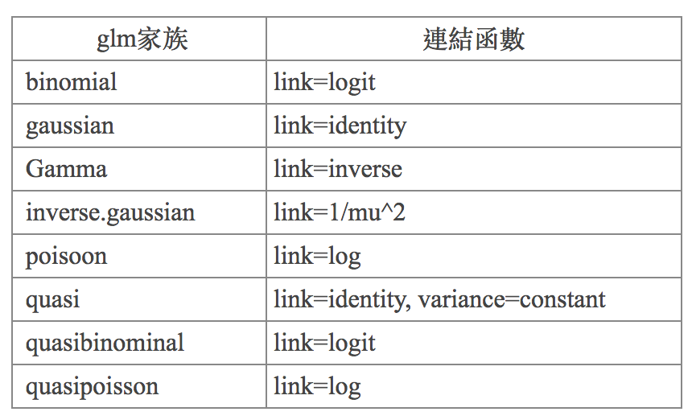

## Logistic Regression

Logistic regression is appropriate when the response variable is categorical with two possible outcomes (i.e., binary outcomes). Binary variables can be represented using an indicator variable $Y_i$, taking on values 0 or 1, and modeled using a binomial distribution with probability $P(Y_i=1) = p_i$. Logistic regression models this probability as a function of one or more explanatory variables.

$P(Y_i=1)=f(t)=\frac{e^{X\beta}}{1+e^{X\beta}}=logit^{-1}(X\beta)$,

$logit(P_i)=\log(\frac{P_i}{1-P_i})=X\beta$

odds: ratio of two probabilities $\frac{p}{1-p}$

Interpretation: e.g. every one unit increase in $X_1$ = $\beta_1$ increase log odds of y.

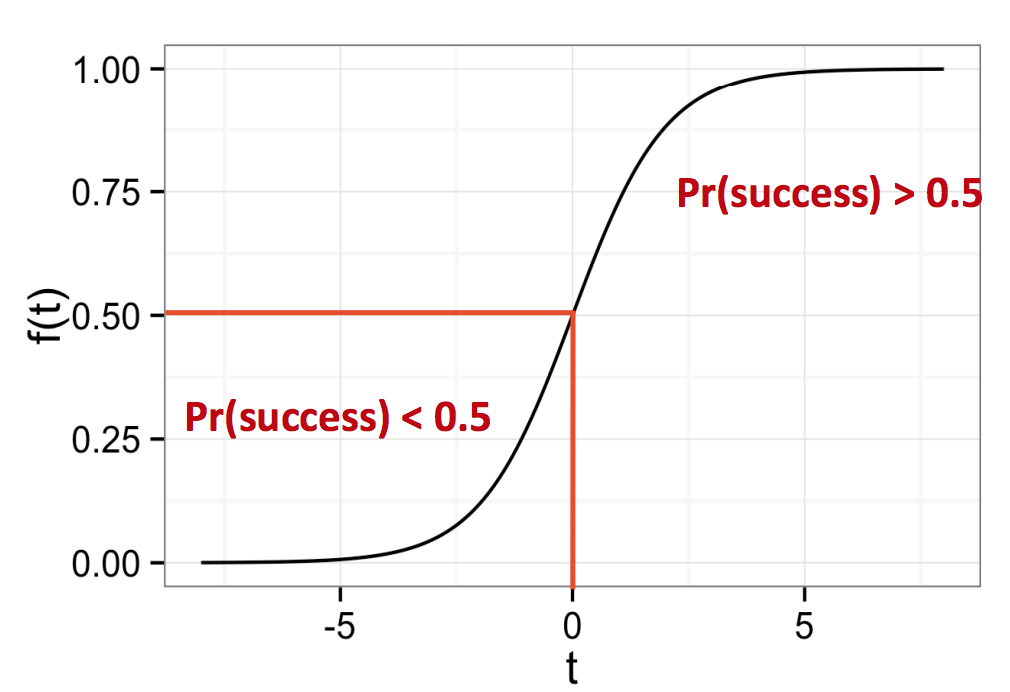

```
glm(response ~ explanantory_variables, family=binomial)
predict.glm(fit)
```

- 勝算Odds $\frac{p}{1-p}$ 發生與沒發生的比值
- 勝算比Odds Ratio (OR) 兩個勝算相除
- 邏輯斯迴歸的迴歸式 $\log ( \text{odds} ) = \text{logit} (P) = \log \left( \frac{P(Y=1) }{1-P(Y=1)} \right) = X\beta$ 故 $exp(\text{logit} (P))$ = 勝算
- 可由勝算回推機率, 機率 = 勝算 / (1 + 勝算)=$\frac{e^{X\beta}}{1+e^{X\beta}}$
- 白話文：“log(勝算) = log (p/(1 - p)) = 迴歸模型”，“勝算比 = 勝算1 / 勝算2”

### Model Validation 表現如何

#### Confusion matrix

`predict(model, new, type = "response")`,

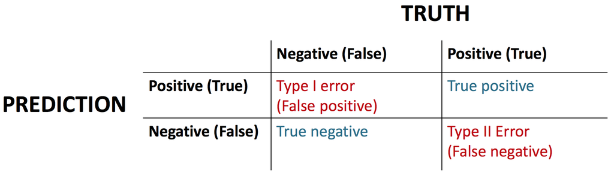

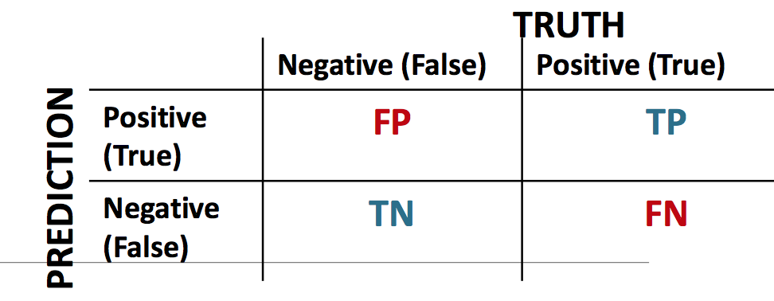

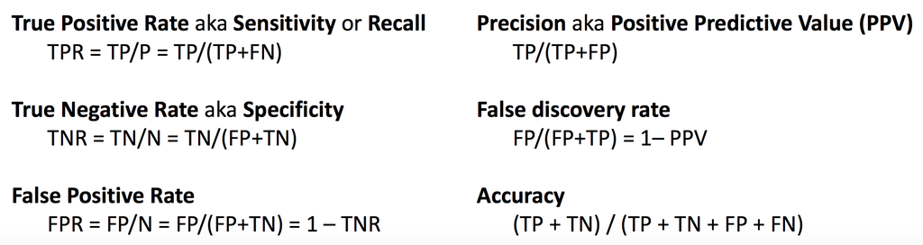

[Ref] https://www.ycc.idv.tw/confusion-matrix.html

### Model selection

#### ROC curve

Receiver Operating Characteristic (ROC) curves are a common  
tool to diagnose the ability of a binary classifier

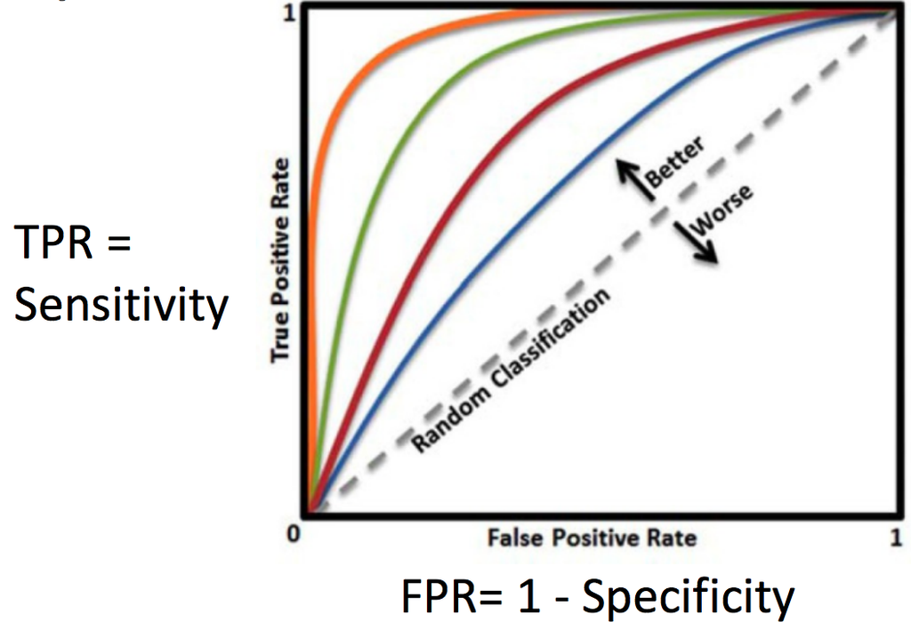

利用曲線下的面積(Area Under Curve; AUC)來判別分類器的鑑別力。以下為AUC數值的判別規則建議：

$\text{AUC }=0.5$ (no discrimination)

$0.7\leq \text{AUC }\leq 0.8$ (acceptable discrimination)

$0.8\leq \text{AUC } \leq 0.9$ (excellent discrimination)

$0.9\leq \text{AUC } \leq 1.0$ (outstanding discrimination)

```
library(InformationValue)

optimalCutoff(real, predicted) # find the best cutoff
confusionMatrix(real, predicted, threshold = 0.5)
misClassError(real, predicted, threshold = 0.5) # error rate
plotROC(real, predicted) #ROC curve
sensitivity(real, predicted, threshold = 0.5)
specificity(real, predicted, threshold = 0.5)
```

Another way:

```
library(pROC)
temp <- roc(real, predicted)
temp$auc
roc.data <- tibble(x = 1-temp$specificities, y = temp$sensitivities)
ggplot(roc.data, aes(x = x, y = y)) +
geom_line() +
ylab("Sensitivity") +
xlab("1-Specificity")
```

## Poisson Regression

Poisson regression models count variables that assumes poisson distribution. When the count variable is over dispersed, having to much variation, Negative Binomial regression is more suitable.

$Y_i\sim Poisson(\mu)$,

$\log(\mu)=X\beta$

$\mu=exp(X\beta)$

Interpretation: e.g. $Y_i\sim Poisson(exp(2.8+0.012X_1-0.2X_2))$

```
library (MASS)
Model <- glm(countResponse ~ x1 + x2, family="poisson", data=Data)
summary(Model)
predict(Model, newdata, type="response")
```

Note: rate 率

Poisson models handle **exposure variables** by using simple algebra to change the dependent variable from a **rate** into a count.

If the rate is **count/exposure**, the final model contains ln(exposure) as a term that is added to the regression coefficients. This logged variable, **ln(exposure)**, is called the **offset variable**補償項. One important feature of an offset variable is that it is required to have a coefficient of 1. This is because it is part of the rate.

Under Poisson process, $\mu=\lambda t$

$Y\sim Poisson(\lambda t)$,

$\log(\lambda_i)=\log(\frac{\mu_i}{t_i})=X\beta$

$\log(\mu_i)-\log(t_i)=X\beta$

$\log(\mu_i)=\log(t_i)+X\beta$

$\log(t_i)$is the offset 補償項 variable. 係數被強制為1

```
#兩種寫法皆可
glm(count ~ x1+x2, offset = log(XXX),family = poisson, data)
glm(count ~ x1+x2 + offset(log(XXX)), family = poisson, data)
```

Sometimes there are many, many more zeros in Y, then need **Zero Inflated Poisson Model**

### Overdispersion 過度離散

We would expect $Var(y)=E(y)$, but often we find $Var(y)>E(y)$.

can check by:

```
#quick chechk:  The rule of thumb is that the ratio of
deviance to df should be 1
summary(model)

library(qcc)
qcc.overdispersion.test(y, type = "poisson") #sig. means overdispersion

#or

library(AER)
dispersiontest(pmodel)
```

Overdispersion means the assumptions of the model are not met, hence we cannot trust its output, so fit other models, like quasipossion, negative binomial

## 配適結果 Goodness of fit test

If the residual deviance is close enough to the residual degrees of freedom, it is a good fit. It can be tested by Chi-squared test.

```
pchisq(deviance(pmodel), df.residual(pmodel), lower.tail=FALSE)
```

$H_0: \text{ deviance} \sim \chi^2 \text{ distribution}$

so reject $H_0$ 表示 不符合卡方分配，可能有過度離散，不是一個好的配適結果。

### Exercise 1

library(ISLR), data: Smarket. Fit a logistic regression model in order to predict `Direction` using `Lag1` through `Lag5` and `Volume`.

1. Use Year 2001~2004 as training data, Year 2005 as test data.
2. Fit a logistic model.
3. Use 0.5 as a cut point to predict direction for Year 2005.
4. Calculate accuracy rate.

### Exercise 2

library(ISwR), Lung cancer example. data(eba1977).

1. Fit a poisson regression model.
2. 檢查是否有過度離散？